# Post-Fire Recovery of Lichen

Max Bonetati

2025-06-10

## 1 Abstract

Wildfire plays an important role in shaping boreal forest ecosystems, yet an increase in fire frequency and severity due to climate change pose threats to slow-growing lichen species that serve as a key winter forage for animals such as the woodland caribou. This study explores how lichen biomass varies across species, forest types, and time since stand-replacing fire (TSSRF) in the boreal of Saskatchewan. Using biomass data from Johnstone et al. (2021), I conducted exploratory visualizations and applied a one-way ANOVA to compare biomass across species, as well as a linear regression to examine the relationship between biomass and TSSRF. The biomass variable was log-transformed to improve normality. Results show significant differences in biomass among species, while the effect of TSSRF was weak and non-significant. These findings suggest species identity is a stronger predictor of biomass recovery than time since the last disturbance. This analysis highlights the need for species-specific conservation strategies in caribou habitat restoration planning.

## 2 Introduction

Lichen communities are important organisms in boreal ecosystems, particularly as a primary winter forage for woodland caribou. These organisms are highly sensitive to ecological disturbances such as wildfire, which have become more frequent and severe in the North American boreal region due to climate change (Whitman et al. 2019). Post-fire forest succession alters the micro climate and substrate conditions, which then affects the biomass and composition of lichen species (Johnstone et al. 2021). Studies have shown that re-establishment of forage lichens can be slow and strongly influenced by forest type and fire severity (Boudreault et al. 2013), making it important to track patterns of biomass across successional gradients. Understanding how lichen biomass and distribution vary with forest type, species identity, and recovery time post-fire can inform conservation and land management strategies for caribou habitat. The dataset used in this analysis was collected by Johnstone et al. (2021) and is publicly available on Dryad. It contains destructive biomass samples of forage lichens across plots in Saskatchewan boreal forests, paired with ecological context such as time since stand-replacing fire, dominant forest type, and percent cover estimates. I hypothesize that lichen biomass is significantly influenced by species identity, forest type, and time since stand-replacing fire, with higher biomass expected in later successional stages and among certain species.

## 3 Exploratory Data Analysis

To explore the distribution of biomass, I first plotted a histogram of log-transformed values (Figure 1). The log transformation reduced the original right-skew and improved the symmetry of the data, although it was still not perfectly normal. However, because the sample size was large enough, the Central Limit Theorem ensures that the sampling distribution of the mean is approximately normal, which justifies the use of parametric tests. A scatterplot of log_biomass against time since stand-replacing fire showed a slight positive trend (Figure 2), suggesting that lichen biomass tends to slightly increase over time following disturbance. Boxplots revealed strong differences in biomass across species, with Cladonia mitis and stereocaulon showing higher values (Figure 3). Forest type also appeared to influence biomass, with jack pine and spruce-dominated stands showing distributions (Figure 4). Overall, these visualizations indicate that both species identity and time since fire somewhat affect biomass patterns, supporting the use of ANOVA and regression in the following analysis.

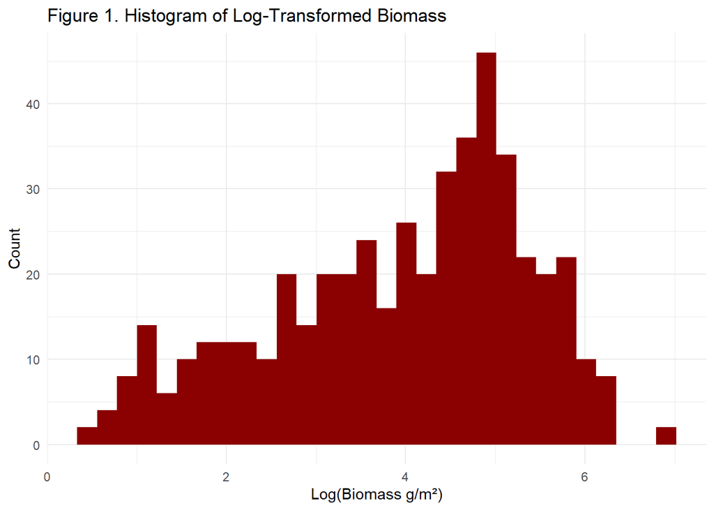

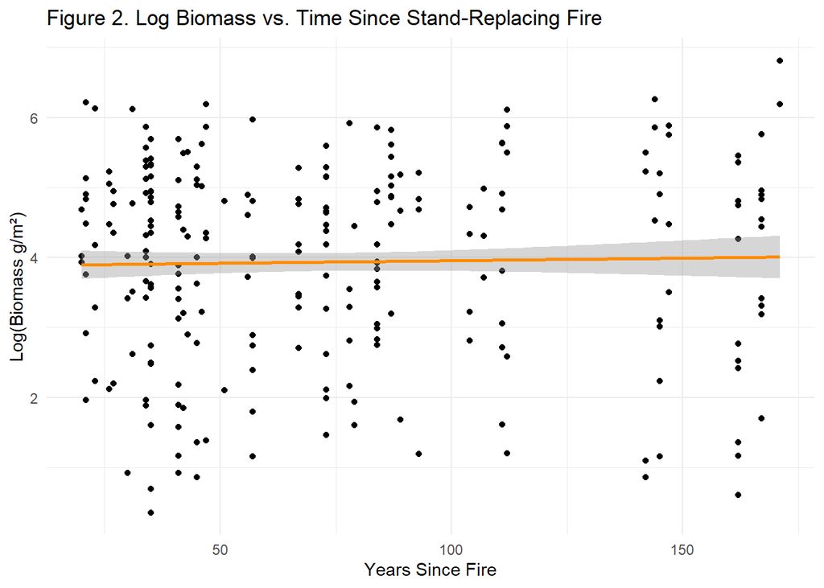

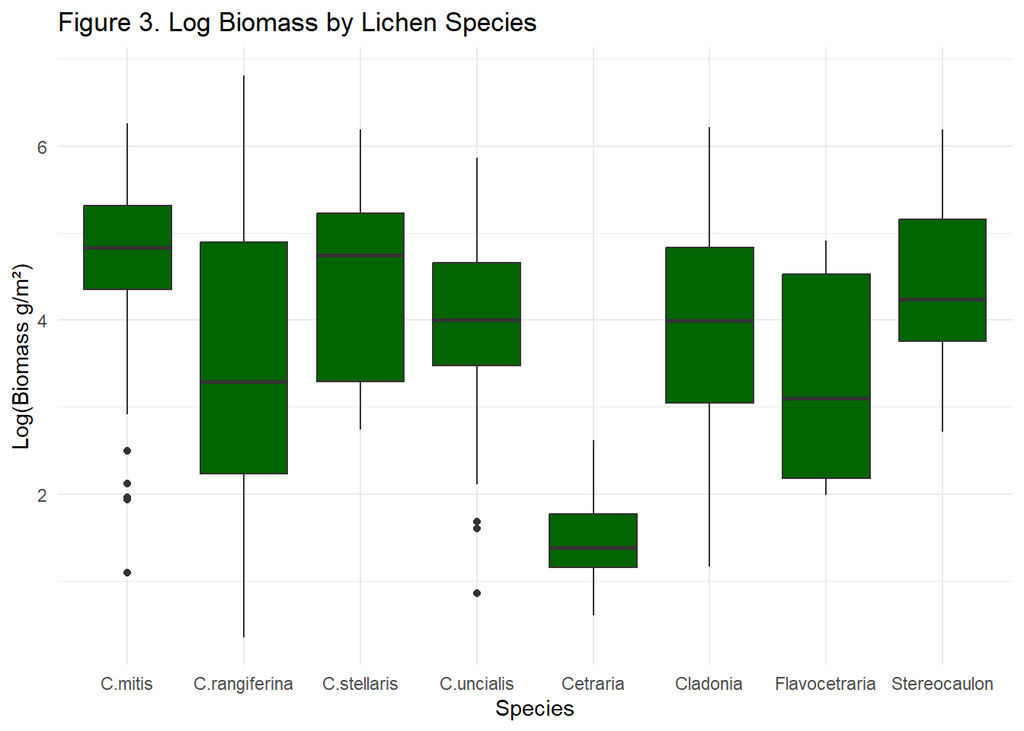

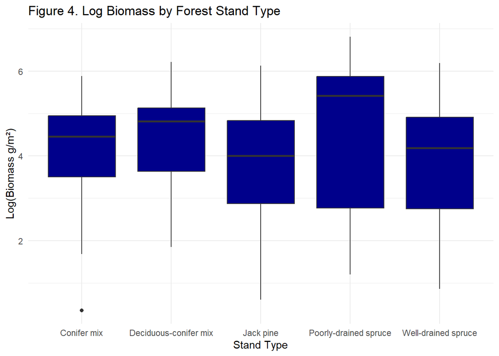

## 4 Statistical Methods

To evaluate how ecological factors influence lichen biomass, I used two statistical models with log-transformed biomass as the response variable. First, I used a one-way ANOVA to compare log-transformed biomass across eight lichen species. This test is appropriate for examining differences in means across multiple categorical groups. The assumptions of normality and homogeneity of variance were assessed using Q-Q plots and a residual vs. fitted plot (Figures A and B), along with Levene’s test. Levene’s test indicated unequal variances across species (F = 9.19, p < 0.001), but ANOVA is generally robust to this violation given a large sample size. The ANOVA yielded a significant result (F(7, 474) = 29.37, p < 2e-16), indicating strong evidence that biomass varies among species. Second, I ran a simple linear regression with time since stand-replacing fire (TSSRF) as the predictor. This test assessed whether biomass increased over time post-fire. Model assumptions were evaluated using residual diagnostics (Figures C and D), which included a residual vs. fitted plot and a Q-Q plot. The regression output showed no significant relationship between biomass and TSSRF (slope = 0.000737, p = 0.615), and the model explained less than 1% of the variance (R² = 0.0005). Figures A–D below display the residual diagnostics for both models.

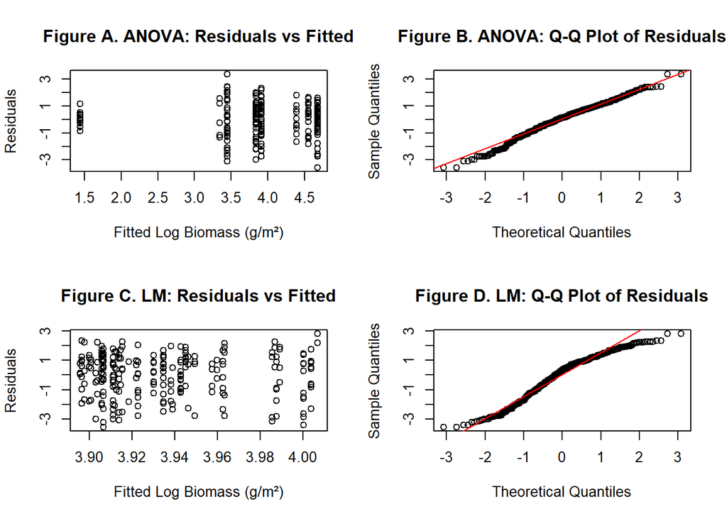

## 5 Results

Table 1. Summary of Statistical Test Results

| Test | Predictor | Test Statistic | p-value | 95% CI for Slope | R² | Conclusion |
| --- | --- | --- | --- | --- | --- | --- |
| One-way ANOVA | Species | F(7, 474) = 29.37 | < 2 × 10⁻¹⁶ | — | — | Reject H₀: Biomass differs by species |
| Linear Regression | TSSRF | t = 0.50, slope = 0.000737 | 0.615 | [-0.0021, 0.0036] | 0.0005 | Fail to reject H₀: No trend with TSSRF |